# Exploration of Loan Data from Prosper

ListingToLoanOriginationDays, albiet expectations, did not display any significant correlation with the other numeric variables.

Let us see if ListingToLoanOriginationDays against the categorical attributes that are most likely to have an impact.

**Impact of the categorical variables on the numer of days before loan orginiation**

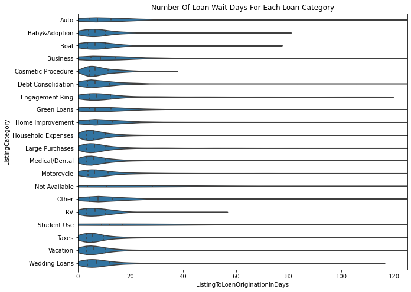

```python
plt.figure(figsize=[10, 8])
sb.violinplot(data=df_clean, y='ListingCategory', x='ListingToLoanOriginationInDays', color=base_color, inner='quartile')
plt.xlim([0, 125])
plt.title('Number Of Loan Wait Days For Each Loan Category');
```

The wait days seem to be fairly uniform across the listing categories.

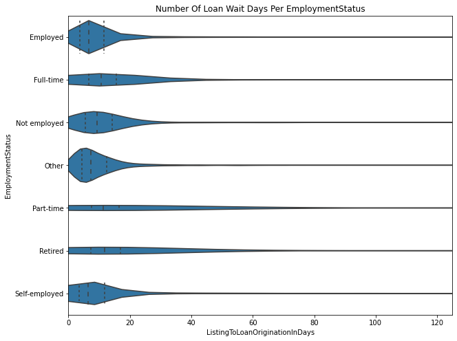

```python
plt.figure(figsize=[10, 8])
sb.violinplot(data=df_clean, y='EmploymentStatus', x='ListingToLoanOriginationInDays', color=base_color, inner='quartile')
plt.xlim([0, 125])
plt.title('Number Of Loan Wait Days Per EmploymentStatus');
```

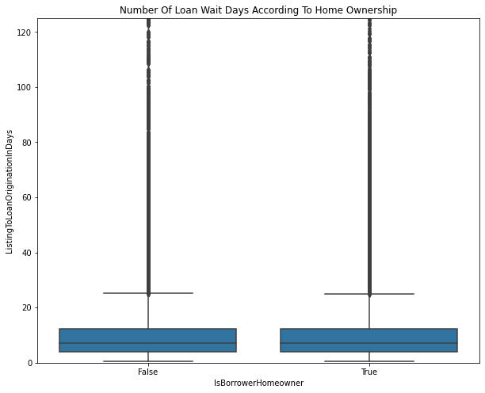

```python
plt.figure(figsize=[10, 8])
sb.boxplot(data=df_clean, x='IsBorrowerHomeowner', y='ListingToLoanOriginationInDays', color=base_color)
plt.ylim([0, 125])
plt.title('Number Of Loan Wait Days According To Home Ownership');
```

**Impact of variables on BorrowerAPR**

BorrowerAPR with Term

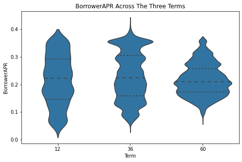

```python
plt.figure(figsize=[8, 5])
sb.violinplot(data=df_clean, x='Term', y='BorrowerAPR', color=base_color, inner='quartile')
plt.title('BorrowerAPR Across The Three Terms');
```

The rarest 12month term has a fairly even distribution of BorrowerAPR rates and the lowest starting point. The 36month term widens around the 0.37 BorrowerAPR value, which also peaked on its own univariate analysis. Makes sense to also get reflected here since the 36months term represent the majority of data points. All in all, the BorrowerAPR medians of all the three terms are very close. A conclusive correlation between the two attributes can not be deduced.

BorrowerAPR With ProsperRating

Since these two display a very high negative correlation of score -0.96 in the above correlation chart, I wanted to take a closer look at the level of impact.

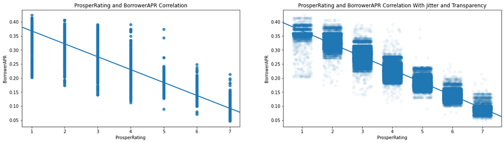

```python
plt.figure(figsize=[20, 5])

plt.subplot(1, 2, 1)
sb.regplot(data=df_clean, x='ProsperRating_numeric', y='BorrowerAPR', truncate=False)
plt.xlabel('ProsperRating')
plt.ylabel('BorrowerAPR')
plt.title('ProsperRating and BorrowerAPR Correlation')

plt.subplot(1, 2, 2)
sb.regplot(data=df_clean, x='ProsperRating_numeric', y='BorrowerAPR', truncate=False, x_jitter=0.3, scatter_kws={'alpha': 1/20})
plt.xlabel('ProsperRating')
plt.ylabel('BorrowerAPR')
plt.title('ProsperRating and BorrowerAPR Correlation With Jitter and Transparency')
```

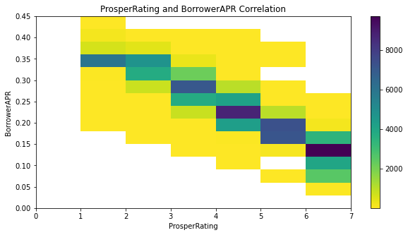

```python
plt.figure(figsize=[10, 5])
bins_x = np.arange(0, df_clean['ProsperRating_numeric'].max()+1, 1)
bins_y = np.arange(0, df_clean['BorrowerAPR'].max()+0.03, 0.03)
plt.hist2d(data=df_clean, x='ProsperRating_numeric', y='BorrowerAPR', bins=[bins_x, bins_y], cmap='viridis_r', cmin=0.03)
plt.colorbar()
plt.xlabel('ProsperRating')
plt.ylabel('BorrowerAPR')
plt.title('ProsperRating and BorrowerAPR Correlation');
```

The negative correlation BorrowerAPR and ProsperRating have makes sense, since a lower rating indicates risk therefore heightened interest rate. And interest rate is the main derivative of the annual percentage rate.

BorrowerAPR with LoanOriginationAmount

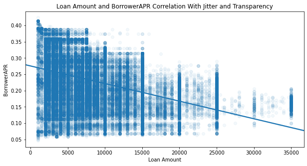

```python
plt.figure(figsize=[10, 5])

sb.regplot(data=df_clean, x='LoanOriginalAmount', y='BorrowerAPR', truncate=False, x_jitter=0.3, scatter_kws={'alpha': 1/20})
plt.xlabel('Loan Amount')
plt.ylabel('BorrowerAPR')
plt.title('Loan Amount and BorrowerAPR Correlation With Jitter and Transparency');
```

BorrowerAPR and LoanOriginalAmount have a negative correlation score of -0.43. Which is expected because for a lender to get an unacceptable return on a low loan amount, the rate would have to be higher. Hence the negative correlation.

BorrowerAPR with IncomeRange

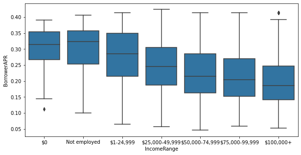

```python
plt.figure(figsize=[10, 5])
order = ['$0', 'Not employed', '$1-24,999', '$25,000-49,999', '$50,000-74,999', '$75,000-99,999', '$100,000+']
sb.boxplot(data=df_clean, x='IncomeRange', y='BorrowerAPR', color=base_color, order=order);
```

We also see a negative correlation between IncomeRange and BorrowerAPR. The higher the income range the lower the APR tends to be.

**Impact of variables on ProsperRating**

ProsperRating with Term

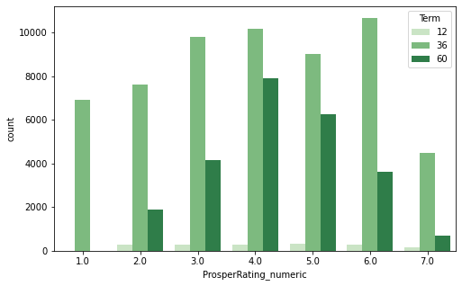

```python
plt.figure(figsize=[8, 5])
sb.countplot(data=df_clean, x='ProsperRating_numeric', hue='Term', palette='Greens');
```

ProsperRating vs DelinquencyRate

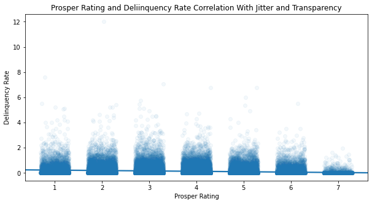

```python
plt.figure(figsize=[10, 5])

sb.regplot(data=df_clean, x='ProsperRating_numeric', y='DelinquencyRate', truncate=False, x_jitter=0.3, scatter_kws={'alpha': 1/20})
plt.xlabel('Prosper Rating')
plt.ylabel('Delinquency Rate')
plt.title('Prosper Rating and Deliinquency Rate Correlation With Jitter and Transparency');
```

The correlation here appears to be very minimal apart from the slight indicaton that the highest rating of 7 being associated with the very lowest spectrum of delinquency rates.

ProsperRating vs EmploymentStatus

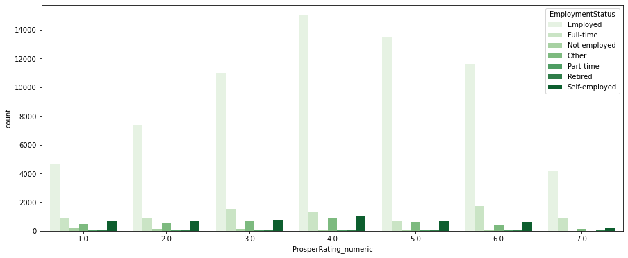

```python
plt.figure(figsize=[15, 6])
sb.countplot(data=df_clean, x='ProsperRating_numeric', hue='EmploymentStatus', palette='Greens');
```

Lets set a limit on the y-axis and zoom in on the data since the count for the status other than 'Employed' appear to be low.

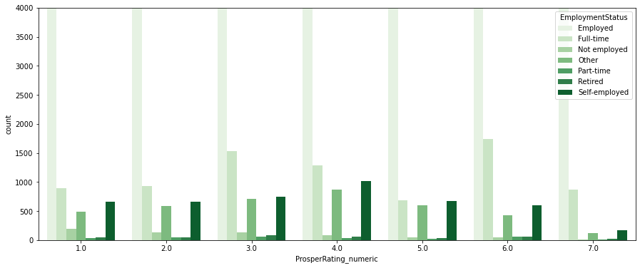

```python
plt.figure(figsize=[15, 6])
sb.countplot(data=df_clean, x='ProsperRating_numeric', hue='EmploymentStatus', palette='Greens')
plt.ylim([0, 4000]);
```

ProsperRating with LoanOriginalAmount

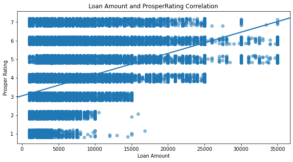

```python
plt.figure(figsize=[10, 5])

sb.regplot(data=df_clean, x='LoanOriginalAmount', y='ProsperRating_numeric', truncate=False, y_jitter=0.2, scatter_kws={'alpha': 0.5})
plt.xlabel('Loan Amount')
plt.ylabel('Prosper Rating')
plt.title('Loan Amount and ProsperRating Correlation');
```

Listings with higher ProsperRatings also seem to get higher loan amounts.

ProsperRating with IncomeRange

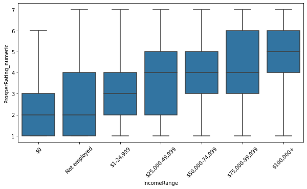

```python
plt.figure(figsize=[10, 5])
order = ['$0', 'Not employed', '$1-24,999', '$25,000-49,999', '$50,000-74,999', '$75,000-99,999', '$100,000+']
sb.boxplot(data=df_clean, x='IncomeRange', y='ProsperRating_numeric', color=base_color, order=order)
plt.xticks(rotation=45);
```

DelinquencyRate with Income Range

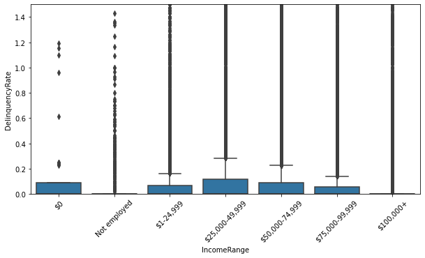

```python
plt.figure(figsize=[10, 5])
order = ['$0', 'Not employed', '$1-24,999', '$25,000-49,999', '$50,000-74,999', '$75,000-99,999', '$100,000+']
sb.boxplot(data=df_clean, x='IncomeRange', y='DelinquencyRate', color=base_color, order=order)
plt.ylim([0, 1.5])
plt.xticks(rotation=45);
```

No meaningful correlation can be deduced.

### Talk about some of the relationships you observed in this part of the investigation. How did the feature(s) of interest vary with other features in the dataset?

To my surprise, there was no indication that the ProsperScore and ProsperRating attributes had any impact on the ListingToLoanOriginationInDays, which is basically the days a borrower had to wait before getting the desired loan, despite my expectations. I expected lower ratings would somehow result in longer wait time since lenders would be reluctant to lend. I was also surprised to not have found meaningful correlation between the categorical variables and the ListingToLoanOriginationInDays attribute.

BorrowerAPR has also shown strong correlations with most of the variables. Having strong negative correlations with ProsperRating, LoanOriginalAmount and MonthlyLoanPayment, which makes sense. It also has slightly positive correlations with DelinquencyRate and DebtToIncomeRatio. The relationship between Term and BorrowerAPR was also analysed but a conclusive correlation between the two attributes could not be deduced.

DelinquencyRate defined as the NumberOfDelinquencies devided by TotalNumberOfLoansTaken, has been observed to have a negative impact on ProsperRating while having a positive correlation with BorrowerAPR and BorrowerRate, both as expected. It also has a slight negative correlation with LoanOriginalAmount and MonthlyLoanPayment.

LoanOriginalAmount and MonthlyLoanAmount appear to positively impact the ProsperRating of a loan lising. While DelinquencyRate and DebtToIncomeRatio display a negative impact on the ratings.

### Did you observe any interesting relationships between the other features (not the main feature(s) of interest)?

StatedMonthlyIncome has shown a positive correlation with LoanOriginalAmount. Which makes sense as borrowers with higher incomes can afford to take out higher loan amounts.

## Multivariate Exploration

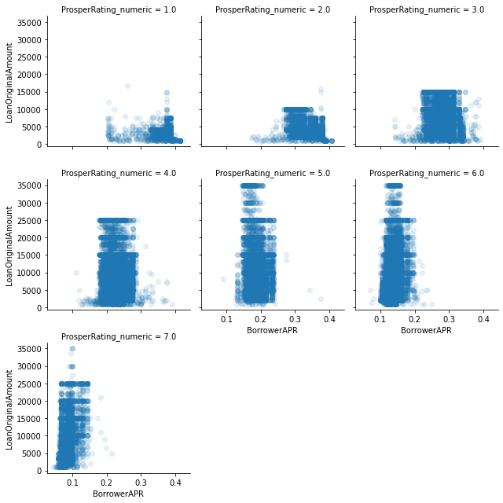

```python
g = sb.FacetGrid(data=df_clean, col='ProsperRating_numeric', col_wrap=3, height=3);
g.map(plt.scatter, 'BorrowerAPR', 'LoanOriginalAmount', alpha= 0.1);
g.set_xlabels('BorrowerAPR');
g.set_ylabels('LoanOriginalAmount');
```

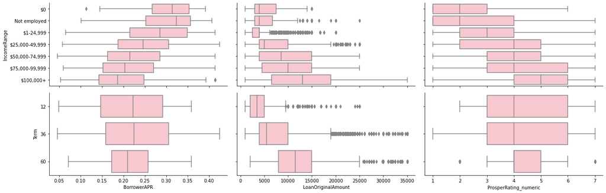

```python
IncomeRangeCategories = ['$0', 'Not employed', '$1-24,999', '$25,000-49,999', '$50,000-74,999', '$75,000-99,999', '$100,000+']
df_clean['IncomeRange'] = pd.Categorical(df_clean['IncomeRange'], categories=IncomeRangeCategories)
g = sb.PairGrid(data=df_clean.sort_values('IncomeRange'), x_vars = ['BorrowerAPR', 'LoanOriginalAmount', 'ProsperRating_numeric'],
                               y_vars=['IncomeRange', 'Term'],
                               height=3, aspect=2)
g.map(sb.boxplot, color='Pink');
```

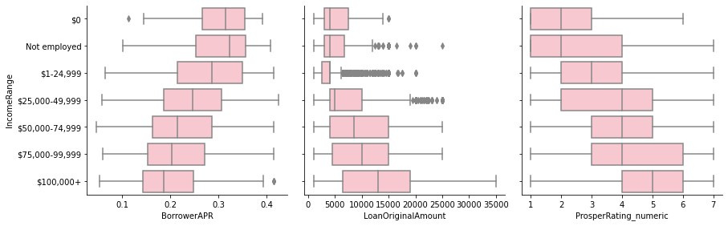

```python
# Exclude Term and zoom in on the IncomeRange part since that appears to have the better impact
plt.figure(figsize=[20, 8]);
IncomeRangeCategories = ['$0', 'Not employed', '$1-24,999', '$25,000-49,999', '$50,000-74,999', '$75,000-99,999', '$100,000+']
df_clean['IncomeRange'] = pd.Categorical(df_clean['IncomeRange'], categories=IncomeRangeCategories)
g = sb.PairGrid(data=df_clean.sort_values('IncomeRange'), x_vars = ['BorrowerAPR', 'LoanOriginalAmount', 'ProsperRating_numeric'],
                               y_vars=['IncomeRange'],
                               height=4, aspect=1);
g.map(sb.boxplot, color='Pink');
```

### Talk about some of the relationships you observed in this part of the investigation. Were there features that strengthened each other in terms of looking at your feature(s) of interest?

IncomeRange had a positive impact on both ProsperRating and BorrowerAPR. Higher ProsperRatings were observed for income ranges on the higher scale, and lower annual percentage rates were awarded to the higher income ranges.

An interesting relationship was observed amongst LoanOriginationAmount, ProsperRating and BorrowerAPR. Loan Amount and Prosper Rating had a positive correlation where an increase in one also correlated with an increase in the other. Prosper Rating and BorrowerAPR also had significant negative correlation where a higher rating meant a lower APR, which is good. Loan Amount starts to show an increase as BorrowerAPR starts to decrease and peaks around the BorrowerAPR value of 0.1 - 0.2, then shows a slight decrease for BorrowerAPR < 0.1.

BorrowerAPR decreases as IncomeRange get higher. While LoanOriginalAmount and ProsperRating increase along with an increase in IncomeRange.

### Were there any interesting or surprising interactions between features?

A Postive correlation between Term and LoanOriginalAmount was observed. Loan Amounts increased as the loan term increased. The majority of the loan amounts were relatively higher for the 60months term.